# Risk Factor Analysis

## Outcome Variable

**Outcome Variable:** co_occurence

## Predictor Variables

**Intervention Variable:** ever_sstunted06

**Adjustment Set:**

- sex
- arm
- enstunt
- month
- brthmon
- hhwealth_quart
- W_birthwt
- W_birthlen
- W_mage
- W_mhtcm
- W_meducyrs
- W_feducyrs
- delta_month
- delta_brthmon
- delta_hhwealth_quart
- delta_W_birthwt
- delta_W_birthlen
- delta_W_mage
- delta_W_mhtcm
- delta_W_meducyrs
- delta_W_feducyrs

## Stratifying Variables

The analysis was stratified on these variable(s):

- studyid
- country

## Data Summary

| studyid | country | ever_sstunted06 | co_occurence | n_cell | n |
| --- | --- | --- | --- | --- | --- |
| ki0047075b-MAL-ED | BANGLADESH | 0 | 0 | 195 | 221 |
| ki0047075b-MAL-ED | BANGLADESH | 0 | 1 | 12 | 221 |
| ki0047075b-MAL-ED | BANGLADESH | 1 | 0 | 12 | 221 |
| ki0047075b-MAL-ED | BANGLADESH | 1 | 1 | 2 | 221 |
| ki0047075b-MAL-ED | BRAZIL | 0 | 0 | 168 | 180 |
| ki0047075b-MAL-ED | BRAZIL | 0 | 1 | 0 | 180 |
| ki0047075b-MAL-ED | BRAZIL | 1 | 0 | 11 | 180 |
| ki0047075b-MAL-ED | BRAZIL | 1 | 1 | 1 | 180 |
| ki0047075b-MAL-ED | INDIA | 0 | 0 | 196 | 228 |
| ki0047075b-MAL-ED | INDIA | 0 | 1 | 14 | 228 |
| ki0047075b-MAL-ED | INDIA | 1 | 0 | 15 | 228 |
| ki0047075b-MAL-ED | INDIA | 1 | 1 | 3 | 228 |
| ki0047075b-MAL-ED | NEPAL | 0 | 0 | 217 | 229 |
| ki0047075b-MAL-ED | NEPAL | 0 | 1 | 4 | 229 |
| ki0047075b-MAL-ED | NEPAL | 1 | 0 | 8 | 229 |
| ki0047075b-MAL-ED | NEPAL | 1 | 1 | 0 | 229 |
| ki0047075b-MAL-ED | PERU | 0 | 0 | 190 | 222 |
| ki0047075b-MAL-ED | PERU | 0 | 1 | 2 | 222 |
| ki0047075b-MAL-ED | PERU | 1 | 0 | 26 | 222 |
| ki0047075b-MAL-ED | PERU | 1 | 1 | 4 | 222 |
| ki0047075b-MAL-ED | SOUTH AFRICA | 0 | 0 | 215 | 241 |
| ki0047075b-MAL-ED | SOUTH AFRICA | 0 | 1 | 3 | 241 |
| ki0047075b-MAL-ED | SOUTH AFRICA | 1 | 0 | 22 | 241 |
| ki0047075b-MAL-ED | SOUTH AFRICA | 1 | 1 | 1 | 241 |
| ki0047075b-MAL-ED | TANZANIA, UNITED REPUBLIC OF | 0 | 0 | 195 | 225 |
| ki0047075b-MAL-ED | TANZANIA, UNITED REPUBLIC OF | 0 | 1 | 0 | 225 |
| ki0047075b-MAL-ED | TANZANIA, UNITED REPUBLIC OF | 1 | 0 | 29 | 225 |
| ki0047075b-MAL-ED | TANZANIA, UNITED REPUBLIC OF | 1 | 1 | 1 | 225 |
| ki1000108-CMC-V-BCS-2002 | INDIA | 0 | 0 | 261 | 364 |
| ki1000108-CMC-V-BCS-2002 | INDIA | 0 | 1 | 12 | 364 |

[output cut: 102 more lines]

The following strata were considered:

- studyid: ki0047075b-MAL-ED, country: BANGLADESH
- studyid: ki0047075b-MAL-ED, country: BRAZIL
- studyid: ki0047075b-MAL-ED, country: INDIA
- studyid: ki0047075b-MAL-ED, country: NEPAL
- studyid: ki0047075b-MAL-ED, country: PERU
- studyid: ki0047075b-MAL-ED, country: SOUTH AFRICA
- studyid: ki0047075b-MAL-ED, country: TANZANIA, UNITED REPUBLIC OF
- studyid: ki1000108-CMC-V-BCS-2002, country: INDIA
- studyid: ki1000108-IRC, country: INDIA
- studyid: ki1000109-EE, country: PAKISTAN
- studyid: ki1000109-ResPak, country: PAKISTAN
- studyid: ki1000304b-SAS-CompFeed, country: INDIA
- studyid: ki1000304b-SAS-FoodSuppl, country: INDIA
- studyid: ki1017093-NIH-Birth, country: BANGLADESH
- studyid: ki1017093b-PROVIDE, country: BANGLADESH
- studyid: ki1017093c-NIH-Crypto, country: BANGLADESH
- studyid: ki1066203-TanzaniaChild2, country: TANZANIA, UNITED REPUBLIC OF
- studyid: ki1101329-Keneba, country: GAMBIA
- studyid: ki1112895-Burkina Faso Zn, country: BURKINA FASO
- studyid: ki1113344-GMS-Nepal, country: NEPAL
- studyid: ki1114097-CMIN, country: BANGLADESH
- studyid: ki1114097-CMIN, country: BRAZIL
- studyid: ki1114097-CMIN, country: GUINEA-BISSAU
- studyid: ki1114097-CMIN, country: PERU
- studyid: ki1114097-CONTENT, country: PERU
- studyid: ki1119695-PROBIT, country: BELARUS
- studyid: ki1126311-ZVITAMBO, country: ZIMBABWE
- studyid: ki1135781-COHORTS, country: GUATEMALA
- studyid: ki1135781-COHORTS, country: PHILIPPINES
- studyid: ki1148112-iLiNS-DOSE, country: MALAWI
- studyid: ki1148112-iLiNS-DYAD-M, country: MALAWI
- studyid: ki1148112-LCNI-5, country: MALAWI
- studyid: kiGH5241-JiVitA-4, country: BANGLADESH

### Dropped Strata

Some strata were dropped due to rare outcomes:

- studyid: ki0047075b-MAL-ED, country: BANGLADESH
- studyid: ki0047075b-MAL-ED, country: BRAZIL
- studyid: ki0047075b-MAL-ED, country: INDIA
- studyid: ki0047075b-MAL-ED, country: NEPAL
- studyid: ki0047075b-MAL-ED, country: PERU
- studyid: ki0047075b-MAL-ED, country: SOUTH AFRICA
- studyid: ki0047075b-MAL-ED, country: TANZANIA, UNITED REPUBLIC OF
- studyid: ki1000109-ResPak, country: PAKISTAN
- studyid: ki1017093b-PROVIDE, country: BANGLADESH
- studyid: ki1066203-TanzaniaChild2, country: TANZANIA, UNITED REPUBLIC OF
- studyid: ki1112895-Burkina Faso Zn, country: BURKINA FASO
- studyid: ki1114097-CMIN, country: BRAZIL
- studyid: ki1114097-CMIN, country: GUINEA-BISSAU
- studyid: ki1114097-CMIN, country: PERU
- studyid: ki1114097-CONTENT, country: PERU
- studyid: ki1119695-PROBIT, country: BELARUS
- studyid: ki1148112-iLiNS-DYAD-M, country: MALAWI
- studyid: ki1148112-LCNI-5, country: MALAWI

## Methods Detail

We’re interested in the causal parameters $E[Y_a]$ for all values of $a \in \mathcal{A}$. These parameters represent the mean outcome if, possibly contrary to fact, we intervened to set all units to have $A=a$. Under the randomization and positivity assumptions, these are identified by the statistical parameters $\psi_a=E_W[E_{Y|A,W}(Y|A=a,W)]$. In addition, we’re interested in the mean of $Y$, $E[Y]$ under no intervention (the observed mean). We will estimate these parameters by using SuperLearner to fit the relevant likelihood factors – $E_{Y|A,W}(Y|A=a,W)$ and $p(A=a|W)$, and then updating our likelihood fit using a joint TMLE.

For unadjusted analyses ($W=\{\}$), initial likelihoods were estimated using Lrnr_glm to estimate the simple $E(Y|A)$ and Lrnr_mean to estimate $p(A)$. For adjusted analyses, a small library containing Lrnr_glmnet, Lrnr_xgboost, and Lrnr_mean was used.

Having estimated these parameters, we will then use the delta method to estimate relative risks and attributable risks relative to a prespecified baseline level of $A$.

# Results Detail

## Results Plots

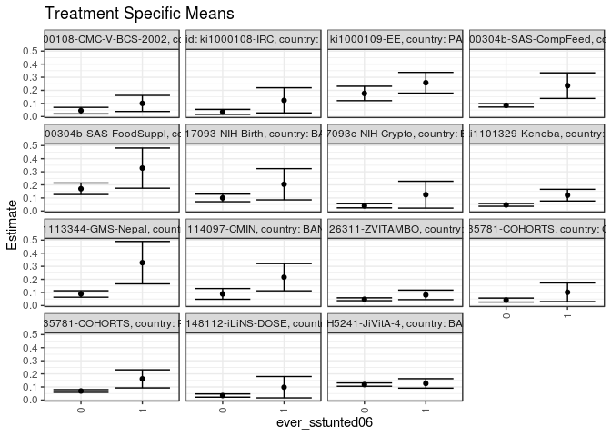

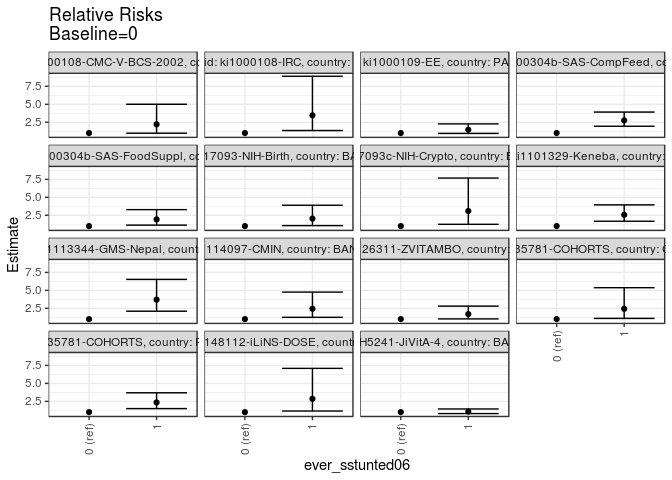

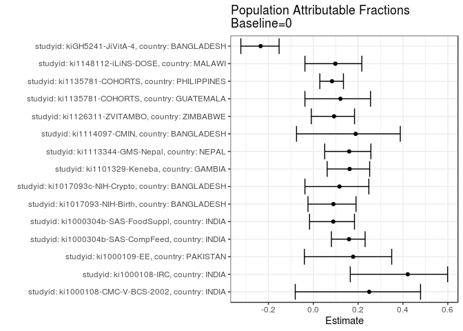

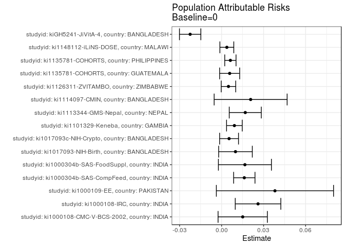

## Results Table

### Parameter: TSM

| studyid | country | intervention_level | baseline_level | estimate | ci_lower | ci_upper |
| --- | --- | --- | --- | --- | --- | --- |
| ki1000108-CMC-V-BCS-2002 | INDIA | 0 | NA | 0.0453678 | 0.0206016 | 0.0701340 |
| ki1000108-CMC-V-BCS-2002 | INDIA | 1 | NA | 0.1001358 | 0.0389436 | 0.1613280 |
| ki1000108-IRC | INDIA | 0 | NA | 0.0357077 | 0.0166643 | 0.0547511 |
| ki1000108-IRC | INDIA | 1 | NA | 0.1236823 | 0.0275284 | 0.2198361 |
| ki1000109-EE | PAKISTAN | 0 | NA | 0.1761846 | 0.1209888 | 0.2313805 |
| ki1000109-EE | PAKISTAN | 1 | NA | 0.2580577 | 0.1789041 | 0.3372113 |
| ki1000304b-SAS-CompFeed | INDIA | 0 | NA | 0.0855379 | 0.0725737 | 0.0985021 |
| ki1000304b-SAS-CompFeed | INDIA | 1 | NA | 0.2359781 | 0.1383464 | 0.3336099 |
| ki1000304b-SAS-FoodSuppl | INDIA | 0 | NA | 0.1702694 | 0.1264770 | 0.2140618 |
| ki1000304b-SAS-FoodSuppl | INDIA | 1 | NA | 0.3280024 | 0.1745766 | 0.4814283 |
| ki1017093-NIH-Birth | BANGLADESH | 0 | NA | 0.1004785 | 0.0716267 | 0.1293303 |
| ki1017093-NIH-Birth | BANGLADESH | 1 | NA | 0.2045455 | 0.0852305 | 0.3238604 |
| ki1017093c-NIH-Crypto | BANGLADESH | 0 | NA | 0.0404040 | 0.0245568 | 0.0562513 |
| ki1017093c-NIH-Crypto | BANGLADESH | 1 | NA | 0.1250000 | 0.0224301 | 0.2275699 |
| ki1101329-Keneba | GAMBIA | 0 | NA | 0.0472327 | 0.0367385 | 0.0577269 |
| ki1101329-Keneba | GAMBIA | 1 | NA | 0.1213846 | 0.0766165 | 0.1661527 |
| ki1113344-GMS-Nepal | NEPAL | 0 | NA | 0.0885543 | 0.0640313 | 0.1130773 |
| ki1113344-GMS-Nepal | NEPAL | 1 | NA | 0.3276396 | 0.1656741 | 0.4896051 |
| ki1114097-CMIN | BANGLADESH | 0 | NA | 0.0889631 | 0.0477758 | 0.1301503 |
| ki1114097-CMIN | BANGLADESH | 1 | NA | 0.2164973 | 0.1123875 | 0.3206072 |
| ki1126311-ZVITAMBO | ZIMBABWE | 0 | NA | 0.0479883 | 0.0369285 | 0.0590482 |
| ki1126311-ZVITAMBO | ZIMBABWE | 1 | NA | 0.0813794 | 0.0450051 | 0.1177536 |
| ki1135781-COHORTS | GUATEMALA | 0 | NA | 0.0417957 | 0.0263527 | 0.0572386 |
| ki1135781-COHORTS | GUATEMALA | 1 | NA | 0.1014493 | 0.0301602 | 0.1727384 |
| ki1135781-COHORTS | PHILIPPINES | 0 | NA | 0.0689251 | 0.0585034 | 0.0793469 |
| ki1135781-COHORTS | PHILIPPINES | 1 | NA | 0.1617809 | 0.0926610 | 0.2309007 |
| ki1148112-iLiNS-DOSE | MALAWI | 0 | NA | 0.0343137 | 0.0218167 | 0.0468107 |
| ki1148112-iLiNS-DOSE | MALAWI | 1 | NA | 0.0980392 | 0.0163796 | 0.1796988 |
| kiGH5241-JiVitA-4 | BANGLADESH | 0 | NA | 0.1180980 | 0.1054113 | 0.1307846 |
| kiGH5241-JiVitA-4 | BANGLADESH | 1 | NA | 0.1268513 | 0.0907621 | 0.1629404 |

### Parameter: E(Y)

| studyid | country | intervention_level | baseline_level | estimate | ci_lower | ci_upper |
| --- | --- | --- | --- | --- | --- | --- |
| ki1000108-CMC-V-BCS-2002 | INDIA | NA | NA | 0.0604396 | 0.0359254 | 0.0849538 |
| ki1000108-IRC | INDIA | NA | NA | 0.0617284 | 0.0382610 | 0.0851958 |
| ki1000109-EE | PAKISTAN | NA | NA | 0.2142857 | 0.1712366 | 0.2573348 |
| ki1000304b-SAS-CompFeed | INDIA | NA | NA | 0.1017488 | 0.0903508 | 0.1131468 |
| ki1000304b-SAS-FoodSuppl | INDIA | NA | NA | 0.1869159 | 0.1442025 | 0.2296293 |
| ki1017093-NIH-Birth | BANGLADESH | NA | NA | 0.1103896 | 0.0817833 | 0.1389959 |
| ki1017093c-NIH-Crypto | BANGLADESH | NA | NA | 0.0457413 | 0.0294659 | 0.0620168 |
| ki1101329-Keneba | GAMBIA | NA | NA | 0.0563698 | 0.0456344 | 0.0671052 |
| ki1113344-GMS-Nepal | NEPAL | NA | NA | 0.1054545 | 0.0797627 | 0.1311464 |
| ki1114097-CMIN | BANGLADESH | NA | NA | 0.1097046 | 0.0698323 | 0.1495770 |
| ki1126311-ZVITAMBO | ZIMBABWE | NA | NA | 0.0528846 | 0.0421282 | 0.0636410 |
| ki1135781-COHORTS | GUATEMALA | NA | NA | 0.0475524 | 0.0319423 | 0.0631626 |
| ki1135781-COHORTS | PHILIPPINES | NA | NA | 0.0751910 | 0.0648251 | 0.0855569 |
| ki1148112-iLiNS-DOSE | MALAWI | NA | NA | 0.0380623 | 0.0253182 | 0.0508064 |
| kiGH5241-JiVitA-4 | BANGLADESH | NA | NA | 0.0956346 | 0.0850945 | 0.1061746 |

### Parameter: RR

| studyid | country | intervention_level | baseline_level | estimate | ci_lower | ci_upper |
| --- | --- | --- | --- | --- | --- | --- |
| ki1000108-CMC-V-BCS-2002 | INDIA | 0 | 0 | 1.000000 | 1.0000000 | 1.000000 |
| ki1000108-CMC-V-BCS-2002 | INDIA | 1 | 0 | 2.207199 | 0.9739765 | 5.001896 |
| ki1000108-IRC | INDIA | 0 | 0 | 1.000000 | 1.0000000 | 1.000000 |
| ki1000108-IRC | INDIA | 1 | 0 | 3.463739 | 1.3471723 | 8.905684 |
| ki1000109-EE | PAKISTAN | 0 | 0 | 1.000000 | 1.0000000 | 1.000000 |
| ki1000109-EE | PAKISTAN | 1 | 0 | 1.464700 | 0.9456884 | 2.268556 |
| ki1000304b-SAS-CompFeed | INDIA | 0 | 0 | 1.000000 | 1.0000000 | 1.000000 |
| ki1000304b-SAS-CompFeed | INDIA | 1 | 0 | 2.758756 | 1.9428577 | 3.917288 |
| ki1000304b-SAS-FoodSuppl | INDIA | 0 | 0 | 1.000000 | 1.0000000 | 1.000000 |
| ki1000304b-SAS-FoodSuppl | INDIA | 1 | 0 | 1.926374 | 1.1294271 | 3.285661 |
| ki1017093-NIH-Birth | BANGLADESH | 0 | 0 | 1.000000 | 1.0000000 | 1.000000 |
| ki1017093-NIH-Birth | BANGLADESH | 1 | 0 | 2.035714 | 1.0625635 | 3.900127 |
| ki1017093c-NIH-Crypto | BANGLADESH | 0 | 0 | 1.000000 | 1.0000000 | 1.000000 |
| ki1017093c-NIH-Crypto | BANGLADESH | 1 | 0 | 3.093750 | 1.2459572 | 7.681876 |
| ki1101329-Keneba | GAMBIA | 0 | 0 | 1.000000 | 1.0000000 | 1.000000 |
| ki1101329-Keneba | GAMBIA | 1 | 0 | 2.569929 | 1.6726883 | 3.948456 |
| ki1113344-GMS-Nepal | NEPAL | 0 | 0 | 1.000000 | 1.0000000 | 1.000000 |
| ki1113344-GMS-Nepal | NEPAL | 1 | 0 | 3.699873 | 2.0982428 | 6.524058 |
| ki1114097-CMIN | BANGLADESH | 0 | 0 | 1.000000 | 1.0000000 | 1.000000 |
| ki1114097-CMIN | BANGLADESH | 1 | 0 | 2.433565 | 1.2442623 | 4.759637 |
| ki1126311-ZVITAMBO | ZIMBABWE | 0 | 0 | 1.000000 | 1.0000000 | 1.000000 |
| ki1126311-ZVITAMBO | ZIMBABWE | 1 | 0 | 1.695815 | 1.0255580 | 2.804122 |
| ki1135781-COHORTS | GUATEMALA | 0 | 0 | 1.000000 | 1.0000000 | 1.000000 |
| ki1135781-COHORTS | GUATEMALA | 1 | 0 | 2.427268 | 1.0972869 | 5.369269 |
| ki1135781-COHORTS | PHILIPPINES | 0 | 0 | 1.000000 | 1.0000000 | 1.000000 |
| ki1135781-COHORTS | PHILIPPINES | 1 | 0 | 2.347197 | 1.4921216 | 3.692281 |
| ki1148112-iLiNS-DOSE | MALAWI | 0 | 0 | 1.000000 | 1.0000000 | 1.000000 |
| ki1148112-iLiNS-DOSE | MALAWI | 1 | 0 | 2.857143 | 1.1511385 | 7.091471 |
| kiGH5241-JiVitA-4 | BANGLADESH | 0 | 0 | 1.000000 | 1.0000000 | 1.000000 |
| kiGH5241-JiVitA-4 | BANGLADESH | 1 | 0 | 1.074119 | 0.8017082 | 1.439091 |

### Parameter: PAR

| studyid | country | intervention_level | baseline_level | estimate | ci_lower | ci_upper |
| --- | --- | --- | --- | --- | --- | --- |
| ki1000108-CMC-V-BCS-2002 | INDIA | 0 | NA | 0.0150717 | -0.0025332 | 0.0326767 |
| ki1000108-IRC | INDIA | 0 | NA | 0.0260207 | 0.0097463 | 0.0422951 |
| ki1000109-EE | PAKISTAN | 0 | NA | 0.0381011 | -0.0037524 | 0.0799546 |
| ki1000304b-SAS-CompFeed | INDIA | 0 | NA | 0.0162109 | 0.0085818 | 0.0238400 |
| ki1000304b-SAS-FoodSuppl | INDIA | 0 | NA | 0.0166465 | -0.0022891 | 0.0355822 |
| ki1017093-NIH-Birth | BANGLADESH | 0 | NA | 0.0099111 | -0.0021077 | 0.0219300 |
| ki1017093c-NIH-Crypto | BANGLADESH | 0 | NA | 0.0053373 | -0.0014040 | 0.0120785 |
| ki1101329-Keneba | GAMBIA | 0 | NA | 0.0091371 | 0.0035406 | 0.0147336 |
| ki1113344-GMS-Nepal | NEPAL | 0 | NA | 0.0169003 | 0.0054583 | 0.0283422 |
| ki1114097-CMIN | BANGLADESH | 0 | NA | 0.0207416 | -0.0053242 | 0.0468073 |
| ki1126311-ZVITAMBO | ZIMBABWE | 0 | NA | 0.0048963 | -0.0002821 | 0.0100746 |
| ki1135781-COHORTS | GUATEMALA | 0 | NA | 0.0057568 | -0.0014000 | 0.0129136 |
| ki1135781-COHORTS | PHILIPPINES | 0 | NA | 0.0062658 | 0.0022389 | 0.0102928 |
| ki1148112-iLiNS-DOSE | MALAWI | 0 | NA | 0.0037486 | -0.0012124 | 0.0087095 |
| kiGH5241-JiVitA-4 | BANGLADESH | 0 | NA | -0.0224634 | -0.0301066 | -0.0148203 |

### Parameter: PAF

| studyid | country | intervention_level | baseline_level | estimate | ci_lower | ci_upper |
| --- | --- | --- | --- | --- | --- | --- |
| ki1000108-CMC-V-BCS-2002 | INDIA | 0 | NA | 0.2493687 | -0.0805057 | 0.4785336 |
| ki1000108-IRC | INDIA | 0 | NA | 0.4215349 | 0.1649934 | 0.5992584 |
| ki1000109-EE | PAKISTAN | 0 | NA | 0.1778051 | -0.0397724 | 0.3498535 |
| ki1000304b-SAS-CompFeed | INDIA | 0 | NA | 0.1593230 | 0.0808252 | 0.2311170 |
| ki1000304b-SAS-FoodSuppl | INDIA | 0 | NA | 0.0890589 | -0.0166418 | 0.1837698 |
| ki1017093-NIH-Birth | BANGLADESH | 0 | NA | 0.0897833 | -0.0236861 | 0.1906753 |
| ki1017093c-NIH-Crypto | BANGLADESH | 0 | NA | 0.1166841 | -0.0372773 | 0.2477932 |
| ki1101329-Keneba | GAMBIA | 0 | NA | 0.1620924 | 0.0619351 | 0.2515558 |
| ki1113344-GMS-Nepal | NEPAL | 0 | NA | 0.1602610 | 0.0509229 | 0.2570028 |
| ki1114097-CMIN | BANGLADESH | 0 | NA | 0.1890675 | -0.0747705 | 0.3881378 |
| ki1126311-ZVITAMBO | ZIMBABWE | 0 | NA | 0.0925841 | -0.0090126 | 0.1839511 |
| ki1135781-COHORTS | GUATEMALA | 0 | NA | 0.1210617 | -0.0373376 | 0.2552739 |
| ki1135781-COHORTS | PHILIPPINES | 0 | NA | 0.0833325 | 0.0290776 | 0.1345555 |
| ki1148112-iLiNS-DOSE | MALAWI | 0 | NA | 0.0984848 | -0.0372119 | 0.2164286 |
| kiGH5241-JiVitA-4 | BANGLADESH | 0 | NA | -0.2348880 | -0.3232104 | -0.1524611 |